# Plotting Time Series Data from multiple files

Alexandre Bokhobza

**Aim**: Create a figure panel for plotting continuous data (time series).  
Works for plotting Time series data from several data file (excel table).

**Contact**: alexandre.bokhobza@gmail.com

**Reference used for creating this notebook**: Goedhart, J. (2022) DataViz protocols - An introduction to data visualization protocols for wet lab scientists, doi: [10.5281/zenodo.7257808](https://zenodo.org/record/7257808#.Y6LaJXbMIQ8)

### Preparation steps.

1. Loading of the required packages.

The packages are loaded using the function “library”.

*Note: To install packages, use the following function: “install.packages(‘name_of_package’)”*

```r
library(tidyverse)
library(here)
library(shiny)
library(fs)
```

### Important note:

2. Required root folder structure:

For the notebook to work you need to have your root folder structured as follow (press play):

```
..
├── data
│   ├── processed_data
│   └── raw_data
├── output
├── Rmd
└── scripts
```

3. Setting up the ‘Here’ package.

The function “here()” is used to declare the location of the current script as the root for the project folder.  
*As a consequence, no absolute path will be required anymore and the Notebook can be used on any machine given that the folder structure is respected).*  
More info can be found at: [here](https://here.r-lib.org/articles/here.html)

```r
here::i_am("Time_series_plot_for_Ca2+.Rproj")
```

```
here() starts at C:/Users/bokhobza/OneDrive - Universitaet Bern/Documents/R/Time_series_plot_for_Ca2+
```

### Step 1: Create an object that includes the path to the data files.

```r
data_path <- paste(here("data", "raw_data"), list.files(here("data", "raw_data")), sep = "/")
head(data_path)
```

```
[1] "C:/Users/bokhobza/OneDrive - Universitaet Bern/Documents/R/Time_series_plot_for_Ca2+/data/raw_data/2018-10-30_PC3_WT-TG.xlsx"
[2] "C:/Users/bokhobza/OneDrive - Universitaet Bern/Documents/R/Time_series_plot_for_Ca2+/data/raw_data/2018-10-30_PC3+ORAI1mCh-TG.xlsx"
```

### Step 2: Loading (reading) data & generate a ‘nested’ dataframe (dataframe of dataframes)

The data are loaded from the excel files using the function “readxl”.  
The loaded data are included in an “R object” named ‘df_input’ using the character: ‘<-’.  
In addition, the first lanes of the object are visualized using the function “head”.  
*Note: df stands for dataframe (type of data loaded)*

```r
df_input <- map(data_path, readxl::read_excel)
head(df_input)
```

| Time (sec) | "R2 R1" | "R3 R1" | "R4 R1" | "R5 R1" | "R6 R1" | "R7 R1" | "R8 R1" | "R9 R1" | "R10 R1" | "R11 R1" | "R12 R1" | "R13 R1" | "R14 R1" | "R15 R1" | "R16 R1" | "R17 R1" | "R18 R1" | "R19 R1" | "R20 R1" | "R21 R1" | "R22 R1" | "R23 R1" | "R24 R1" | "R25 R1" | "R26 R1" | "R27 R1" | "R28 R1" | "R29 R1" | "R30 R1" | … |
| --- | --- | --- | --- | --- | --- | --- | --- | --- | --- | --- | --- | --- | --- | --- | --- | --- | --- | --- | --- | --- | --- | --- | --- | --- | --- | --- | --- | --- | --- | --- |
| 0.36 | 0.85 | 0.62 | 0.46 | 0.45 | 0.51 | 0.82 | 0.69 | 0.56 | 0.44 | 0.44 | 0.87 | 0.76 | 0.46 | 0.52 | 0.46 | 0.45 | 0.83 | 0.46 | 0.50 | 0.53 | 0.49 | 0.49 | 0.49 | 0.48 | 0.60 | 0.54 | 0.83 | 0.86 | 0.64 | … |
| 5.36 | 0.55 | 0.44 | 0.45 | 0.44 | 0.49 | 0.46 | 0.53 | 0.47 | 0.43 | 0.42 | 0.42 | 0.49 | 0.44 | 0.43 | 0.44 | 0.43 | 0.49 | 0.43 | 0.44 | 0.44 | 0.45 | 0.45 | 0.45 | 0.46 | 0.48 | 0.46 | 0.60 | 0.52 | 0.49 | … |
| 10.36 | 0.82 | 0.47 | 0.46 | 0.44 | 0.50 | 0.72 | 0.58 | 0.50 | 0.44 | 0.42 | 0.52 | 0.60 | 0.45 | 0.46 | 0.45 | 0.44 | 0.58 | 0.44 | 0.47 | 0.47 | 0.47 | 0.47 | 0.47 | 0.47 | 0.52 | 0.54 | 0.66 | 0.61 | 0.60 | … |
| 15.36 | 0.75 | 0.48 | 0.46 | 0.45 | 0.52 | 0.85 | 0.78 | 0.54 | 0.44 | 0.43 | 0.67 | 0.70 | 0.45 | 0.49 | 0.45 | 0.45 | 0.62 | 0.45 | 0.49 | 0.50 | 0.48 | 0.48 | 0.48 | 0.48 | 0.55 | 0.53 | 0.76 | 0.82 | 0.61 | … |
| 20.36 | 0.75 | 0.48 | 0.47 | 0.45 | 0.53 | 0.74 | 0.82 | 0.55 | 0.44 | 0.43 | 0.90 | 0.74 | 0.45 | 0.50 | 0.45 | 0.46 | 0.78 | 0.45 | 0.52 | 0.54 | 0.49 | 0.49 | 0.48 | 0.48 | 0.60 | 0.53 | 0.67 | 0.67 | 0.67 | … |
| 25.36 | 0.51 | 0.44 | 0.45 | 0.44 | 0.48 | 0.46 | 0.48 | 0.48 | 0.43 | 0.41 | 0.44 | 0.48 | 0.43 | 0.44 | 0.43 | 0.43 | 0.48 | 0.43 | 0.45 | 0.44 | 0.45 | 0.45 | 0.45 | 0.46 | 0.48 | 0.47 | 0.46 | 0.47 | 0.48 | … |
| 30.36 | 0.51 | 0.45 | 0.45 | 0.44 | 0.48 | 0.47 | 0.48 | 0.48 | 0.43 | 0.41 | 0.44 | 0.47 | 0.44 | 0.45 | 0.44 | 0.44 | 0.48 | 0.43 | 0.45 | 0.44 | 0.46 | 0.45 | 0.45 | 0.46 | 0.49 | 0.47 | 0.46 | 0.47 | 0.49 | … |
| 35.36 | 0.63 | 0.53 | 0.48 | 0.46 | 0.55 | 0.56 | 0.58 | 0.56 | 0.45 | 0.45 | 0.62 | 0.60 | 0.46 | 0.53 | 0.47 | 0.48 | 0.60 | 0.47 | 0.54 | 0.55 | 0.52 | 0.51 | 0.50 | 0.49 | 0.56 | 0.54 | 0.56 | 0.58 | 0.57 | … |
| 40.36 | 0.53 | 0.46 | 0.45 | 0.44 | 0.48 | 0.48 | 0.50 | 0.49 | 0.44 | 0.42 | 0.46 | 0.50 | 0.44 | 0.46 | 0.45 | 0.44 | 0.50 | 0.43 | 0.47 | 0.46 | 0.46 | 0.46 | 0.46 | 0.47 | 0.50 | 0.48 | 0.47 | 0.48 | 0.50 | … |
| 45.36 | 0.51 | 0.45 | 0.45 | 0.44 | 0.48 | 0.46 | 0.48 | 0.48 | 0.43 | 0.41 | 0.46 | 0.48 | 0.44 | 0.45 | 0.45 | 0.44 | 0.48 | 0.43 | 0.46 | 0.44 | 0.46 | 0.46 | 0.45 | 0.46 | 0.49 | 0.47 | 0.46 | 0.47 | 0.49 | … |

[output cut: 366 more lines]

| Time (sec) | "R2 R1" | "R3 R1" | "R4 R1" | "R5 R1" | "R6 R1" | "R7 R1" | "R8 R1" | "R9 R1" | "R10 R1" | "R11 R1" | "R12 R1" | "R13 R1" | "R14 R1" | "R15 R1" | "R16 R1" | "R17 R1" | "R18 R1" | "R19 R1" | "R20 R1" | "R21 R1" | "R22 R1" | "R23 R1" | "R24 R1" | "R25 R1" | "R26 R1" | "R27 R1" | "R28 R1" | "R29 R1" | "R30 R1" | … |
| --- | --- | --- | --- | --- | --- | --- | --- | --- | --- | --- | --- | --- | --- | --- | --- | --- | --- | --- | --- | --- | --- | --- | --- | --- | --- | --- | --- | --- | --- | --- |
| 0.53 | 0.96 | 0.53 | 0.57 | 0.51 | 0.57 | 0.54 | 0.56 | 0.50 | 0.55 | 0.61 | 0.48 | 0.56 | 0.51 | 0.51 | 0.49 | 0.51 | 0.57 | 0.49 | 0.54 | 0.52 | 0.49 | 0.51 | 0.51 | 0.51 | 0.56 | 0.58 | 0.48 | 0.56 | 0.59 | … |
| 5.53 | 0.97 | 0.53 | 0.55 | 0.51 | 0.56 | 0.54 | 0.56 | 0.50 | 0.55 | 0.59 | 0.48 | 0.55 | 0.50 | 0.50 | 0.48 | 0.50 | 0.56 | 0.47 | 0.53 | 0.52 | 0.50 | 0.51 | 0.50 | 0.51 | 0.55 | 0.62 | 0.48 | 0.54 | 0.58 | … |
| 10.53 | 0.97 | 0.52 | 0.56 | 0.51 | 0.56 | 0.53 | 0.55 | 0.50 | 0.56 | 0.58 | 0.48 | 0.55 | 0.50 | 0.51 | 0.48 | 0.50 | 0.56 | 0.47 | 0.53 | 0.51 | 0.49 | 0.51 | 0.49 | 0.51 | 0.55 | 0.70 | 0.48 | 0.55 | 0.58 | … |
| 15.53 | 0.93 | 0.51 | 0.51 | 0.49 | 0.53 | 0.50 | 0.54 | 0.47 | 0.54 | 0.54 | 0.48 | 0.51 | 0.48 | 0.50 | 0.48 | 0.48 | 0.52 | 0.45 | 0.50 | 0.50 | 0.48 | 0.50 | 0.48 | 0.50 | 0.53 | 0.80 | 0.47 | 0.49 | 0.56 | … |
| 20.53 | 0.94 | 0.51 | 0.53 | 0.50 | 0.55 | 0.52 | 0.55 | 0.49 | 0.58 | 0.59 | 0.48 | 0.52 | 0.49 | 0.51 | 0.48 | 0.49 | 0.55 | 0.46 | 0.52 | 0.51 | 0.49 | 0.50 | 0.49 | 0.50 | 0.53 | 0.90 | 0.47 | 0.52 | 0.57 | … |
| 25.53 | 0.98 | 0.54 | 0.56 | 0.51 | 0.57 | 0.54 | 0.57 | 0.51 | 0.62 | 0.66 | 0.48 | 0.55 | 0.51 | 0.52 | 0.49 | 0.50 | 0.56 | 0.48 | 0.54 | 0.52 | 0.50 | 0.51 | 0.50 | 0.51 | 0.56 | 0.88 | 0.48 | 0.56 | 0.59 | … |
| 30.53 | 0.95 | 0.52 | 0.53 | 0.50 | 0.55 | 0.53 | 0.55 | 0.49 | 0.62 | 0.72 | 0.48 | 0.53 | 0.50 | 0.51 | 0.48 | 0.49 | 0.55 | 0.47 | 0.52 | 0.51 | 0.49 | 0.50 | 0.49 | 0.50 | 0.53 | 0.84 | 0.48 | 0.53 | 0.57 | … |
| 35.53 | 0.97 | 0.54 | 0.56 | 0.51 | 0.57 | 0.54 | 0.57 | 0.51 | 0.67 | 0.77 | 0.48 | 0.56 | 0.52 | 0.52 | 0.49 | 0.50 | 0.57 | 0.48 | 0.53 | 0.52 | 0.50 | 0.51 | 0.51 | 0.51 | 0.56 | 0.89 | 0.49 | 0.57 | 0.59 | … |
| 40.53 | 0.97 | 0.54 | 0.56 | 0.51 | 0.57 | 0.54 | 0.56 | 0.51 | 0.70 | 0.76 | 0.48 | 0.55 | 0.52 | 0.53 | 0.49 | 0.50 | 0.57 | 0.48 | 0.55 | 0.52 | 0.50 | 0.52 | 0.51 | 0.51 | 0.56 | 0.84 | 0.49 | 0.56 | 0.59 | … |
| 45.53 | 0.99 | 0.55 | 0.56 | 0.51 | 0.57 | 0.55 | 0.57 | 0.52 | 0.73 | 0.78 | 0.48 | 0.56 | 0.53 | 0.55 | 0.50 | 0.51 | 0.57 | 0.48 | 0.54 | 0.52 | 0.50 | 0.52 | 0.50 | 0.51 | 0.57 | 0.81 | 0.49 | 0.57 | 0.59 | … |

[output cut: 376 more lines]

```
NA
```

### Step 3: Naming the loaded dataframe according to the files names.

This could be changed by a button to specify the desired name

```r
names(df_input) <- str_replace(list.files(here("data", "raw_data")), pattern = ".xlsx", replacement = "")
head(df_input)
```

```
$`2018-10-30_PC3_WT-TG`
```

| Time (sec) | "R2 R1" | "R3 R1" | "R4 R1" | "R5 R1" | "R6 R1" | "R7 R1" | "R8 R1" | "R9 R1" | "R10 R1" | "R11 R1" | "R12 R1" | "R13 R1" | "R14 R1" | "R15 R1" | "R16 R1" | "R17 R1" | "R18 R1" | "R19 R1" | "R20 R1" | "R21 R1" | "R22 R1" | "R23 R1" | "R24 R1" | "R25 R1" | "R26 R1" | "R27 R1" | "R28 R1" | "R29 R1" | "R30 R1" | … |
| --- | --- | --- | --- | --- | --- | --- | --- | --- | --- | --- | --- | --- | --- | --- | --- | --- | --- | --- | --- | --- | --- | --- | --- | --- | --- | --- | --- | --- | --- | --- |
| 0.36 | 0.85 | 0.62 | 0.46 | 0.45 | 0.51 | 0.82 | 0.69 | 0.56 | 0.44 | 0.44 | 0.87 | 0.76 | 0.46 | 0.52 | 0.46 | 0.45 | 0.83 | 0.46 | 0.50 | 0.53 | 0.49 | 0.49 | 0.49 | 0.48 | 0.60 | 0.54 | 0.83 | 0.86 | 0.64 | … |
| 5.36 | 0.55 | 0.44 | 0.45 | 0.44 | 0.49 | 0.46 | 0.53 | 0.47 | 0.43 | 0.42 | 0.42 | 0.49 | 0.44 | 0.43 | 0.44 | 0.43 | 0.49 | 0.43 | 0.44 | 0.44 | 0.45 | 0.45 | 0.45 | 0.46 | 0.48 | 0.46 | 0.60 | 0.52 | 0.49 | … |
| 10.36 | 0.82 | 0.47 | 0.46 | 0.44 | 0.50 | 0.72 | 0.58 | 0.50 | 0.44 | 0.42 | 0.52 | 0.60 | 0.45 | 0.46 | 0.45 | 0.44 | 0.58 | 0.44 | 0.47 | 0.47 | 0.47 | 0.47 | 0.47 | 0.47 | 0.52 | 0.54 | 0.66 | 0.61 | 0.60 | … |
| 15.36 | 0.75 | 0.48 | 0.46 | 0.45 | 0.52 | 0.85 | 0.78 | 0.54 | 0.44 | 0.43 | 0.67 | 0.70 | 0.45 | 0.49 | 0.45 | 0.45 | 0.62 | 0.45 | 0.49 | 0.50 | 0.48 | 0.48 | 0.48 | 0.48 | 0.55 | 0.53 | 0.76 | 0.82 | 0.61 | … |
| 20.36 | 0.75 | 0.48 | 0.47 | 0.45 | 0.53 | 0.74 | 0.82 | 0.55 | 0.44 | 0.43 | 0.90 | 0.74 | 0.45 | 0.50 | 0.45 | 0.46 | 0.78 | 0.45 | 0.52 | 0.54 | 0.49 | 0.49 | 0.48 | 0.48 | 0.60 | 0.53 | 0.67 | 0.67 | 0.67 | … |
| 25.36 | 0.51 | 0.44 | 0.45 | 0.44 | 0.48 | 0.46 | 0.48 | 0.48 | 0.43 | 0.41 | 0.44 | 0.48 | 0.43 | 0.44 | 0.43 | 0.43 | 0.48 | 0.43 | 0.45 | 0.44 | 0.45 | 0.45 | 0.45 | 0.46 | 0.48 | 0.47 | 0.46 | 0.47 | 0.48 | … |
| 30.36 | 0.51 | 0.45 | 0.45 | 0.44 | 0.48 | 0.47 | 0.48 | 0.48 | 0.43 | 0.41 | 0.44 | 0.47 | 0.44 | 0.45 | 0.44 | 0.44 | 0.48 | 0.43 | 0.45 | 0.44 | 0.46 | 0.45 | 0.45 | 0.46 | 0.49 | 0.47 | 0.46 | 0.47 | 0.49 | … |
| 35.36 | 0.63 | 0.53 | 0.48 | 0.46 | 0.55 | 0.56 | 0.58 | 0.56 | 0.45 | 0.45 | 0.62 | 0.60 | 0.46 | 0.53 | 0.47 | 0.48 | 0.60 | 0.47 | 0.54 | 0.55 | 0.52 | 0.51 | 0.50 | 0.49 | 0.56 | 0.54 | 0.56 | 0.58 | 0.57 | … |
| 40.36 | 0.53 | 0.46 | 0.45 | 0.44 | 0.48 | 0.48 | 0.50 | 0.49 | 0.44 | 0.42 | 0.46 | 0.50 | 0.44 | 0.46 | 0.45 | 0.44 | 0.50 | 0.43 | 0.47 | 0.46 | 0.46 | 0.46 | 0.46 | 0.47 | 0.50 | 0.48 | 0.47 | 0.48 | 0.50 | … |
| 45.36 | 0.51 | 0.45 | 0.45 | 0.44 | 0.48 | 0.46 | 0.48 | 0.48 | 0.43 | 0.41 | 0.46 | 0.48 | 0.44 | 0.45 | 0.45 | 0.44 | 0.48 | 0.43 | 0.46 | 0.44 | 0.46 | 0.46 | 0.45 | 0.46 | 0.49 | 0.47 | 0.46 | 0.47 | 0.49 | … |

[output cut: 366 more lines]

```
$`2018-10-30_PC3+ORAI1mCh-TG`
```

| Time (sec) | "R2 R1" | "R3 R1" | "R4 R1" | "R5 R1" | "R6 R1" | "R7 R1" | "R8 R1" | "R9 R1" | "R10 R1" | "R11 R1" | "R12 R1" | "R13 R1" | "R14 R1" | "R15 R1" | "R16 R1" | "R17 R1" | "R18 R1" | "R19 R1" | "R20 R1" | "R21 R1" | "R22 R1" | "R23 R1" | "R24 R1" | "R25 R1" | "R26 R1" | "R27 R1" | "R28 R1" | "R29 R1" | "R30 R1" | … |
| --- | --- | --- | --- | --- | --- | --- | --- | --- | --- | --- | --- | --- | --- | --- | --- | --- | --- | --- | --- | --- | --- | --- | --- | --- | --- | --- | --- | --- | --- | --- |
| 0.53 | 0.96 | 0.53 | 0.57 | 0.51 | 0.57 | 0.54 | 0.56 | 0.50 | 0.55 | 0.61 | 0.48 | 0.56 | 0.51 | 0.51 | 0.49 | 0.51 | 0.57 | 0.49 | 0.54 | 0.52 | 0.49 | 0.51 | 0.51 | 0.51 | 0.56 | 0.58 | 0.48 | 0.56 | 0.59 | … |
| 5.53 | 0.97 | 0.53 | 0.55 | 0.51 | 0.56 | 0.54 | 0.56 | 0.50 | 0.55 | 0.59 | 0.48 | 0.55 | 0.50 | 0.50 | 0.48 | 0.50 | 0.56 | 0.47 | 0.53 | 0.52 | 0.50 | 0.51 | 0.50 | 0.51 | 0.55 | 0.62 | 0.48 | 0.54 | 0.58 | … |
| 10.53 | 0.97 | 0.52 | 0.56 | 0.51 | 0.56 | 0.53 | 0.55 | 0.50 | 0.56 | 0.58 | 0.48 | 0.55 | 0.50 | 0.51 | 0.48 | 0.50 | 0.56 | 0.47 | 0.53 | 0.51 | 0.49 | 0.51 | 0.49 | 0.51 | 0.55 | 0.70 | 0.48 | 0.55 | 0.58 | … |
| 15.53 | 0.93 | 0.51 | 0.51 | 0.49 | 0.53 | 0.50 | 0.54 | 0.47 | 0.54 | 0.54 | 0.48 | 0.51 | 0.48 | 0.50 | 0.48 | 0.48 | 0.52 | 0.45 | 0.50 | 0.50 | 0.48 | 0.50 | 0.48 | 0.50 | 0.53 | 0.80 | 0.47 | 0.49 | 0.56 | … |
| 20.53 | 0.94 | 0.51 | 0.53 | 0.50 | 0.55 | 0.52 | 0.55 | 0.49 | 0.58 | 0.59 | 0.48 | 0.52 | 0.49 | 0.51 | 0.48 | 0.49 | 0.55 | 0.46 | 0.52 | 0.51 | 0.49 | 0.50 | 0.49 | 0.50 | 0.53 | 0.90 | 0.47 | 0.52 | 0.57 | … |
| 25.53 | 0.98 | 0.54 | 0.56 | 0.51 | 0.57 | 0.54 | 0.57 | 0.51 | 0.62 | 0.66 | 0.48 | 0.55 | 0.51 | 0.52 | 0.49 | 0.50 | 0.56 | 0.48 | 0.54 | 0.52 | 0.50 | 0.51 | 0.50 | 0.51 | 0.56 | 0.88 | 0.48 | 0.56 | 0.59 | … |
| 30.53 | 0.95 | 0.52 | 0.53 | 0.50 | 0.55 | 0.53 | 0.55 | 0.49 | 0.62 | 0.72 | 0.48 | 0.53 | 0.50 | 0.51 | 0.48 | 0.49 | 0.55 | 0.47 | 0.52 | 0.51 | 0.49 | 0.50 | 0.49 | 0.50 | 0.53 | 0.84 | 0.48 | 0.53 | 0.57 | … |
| 35.53 | 0.97 | 0.54 | 0.56 | 0.51 | 0.57 | 0.54 | 0.57 | 0.51 | 0.67 | 0.77 | 0.48 | 0.56 | 0.52 | 0.52 | 0.49 | 0.50 | 0.57 | 0.48 | 0.53 | 0.52 | 0.50 | 0.51 | 0.51 | 0.51 | 0.56 | 0.89 | 0.49 | 0.57 | 0.59 | … |
| 40.53 | 0.97 | 0.54 | 0.56 | 0.51 | 0.57 | 0.54 | 0.56 | 0.51 | 0.70 | 0.76 | 0.48 | 0.55 | 0.52 | 0.53 | 0.49 | 0.50 | 0.57 | 0.48 | 0.55 | 0.52 | 0.50 | 0.52 | 0.51 | 0.51 | 0.56 | 0.84 | 0.49 | 0.56 | 0.59 | … |
| 45.53 | 0.99 | 0.55 | 0.56 | 0.51 | 0.57 | 0.55 | 0.57 | 0.52 | 0.73 | 0.78 | 0.48 | 0.56 | 0.53 | 0.55 | 0.50 | 0.51 | 0.57 | 0.48 | 0.54 | 0.52 | 0.50 | 0.52 | 0.50 | 0.51 | 0.57 | 0.81 | 0.49 | 0.57 | 0.59 | … |

[output cut: 376 more lines]

```
NA
```

### Step4: Merge the dataframes.

A single dataframe with all data is generated.  
A new column named ‘id’ is created to keep the origin of the date (initial filename).

```r
df <- bind_rows(df_input, .id = 'id')
head(df)
```

| id | Time (sec) | "R2 R1" | "R3 R1" | "R4 R1" | "R5 R1" | "R6 R1" | "R7 R1" | "R8 R1" | "R9 R1" | "R10 R1" | "R11 R1" | "R12 R1" | "R13 R1" | "R14 R1" | "R15 R1" | "R16 R1" | "R17 R1" | "R18 R1" | "R19 R1" | "R20 R1" | "R21 R1" | "R22 R1" | "R23 R1" | "R24 R1" | "R25 R1" | "R26 R1" | "R27 R1" | "R28 R1" | "R29 R1" | … |
| --- | --- | --- | --- | --- | --- | --- | --- | --- | --- | --- | --- | --- | --- | --- | --- | --- | --- | --- | --- | --- | --- | --- | --- | --- | --- | --- | --- | --- | --- | --- |
| 2018-10-30_PC3_WT-TG | 0.36 | 0.85 | 0.62 | 0.46 | 0.45 | 0.51 | 0.82 | 0.69 | 0.56 | 0.44 | 0.44 | 0.87 | 0.76 | 0.46 | 0.52 | 0.46 | 0.45 | 0.83 | 0.46 | 0.50 | 0.53 | 0.49 | 0.49 | 0.49 | 0.48 | 0.60 | 0.54 | 0.83 | 0.86 | … |
| 2018-10-30_PC3_WT-TG | 5.36 | 0.55 | 0.44 | 0.45 | 0.44 | 0.49 | 0.46 | 0.53 | 0.47 | 0.43 | 0.42 | 0.42 | 0.49 | 0.44 | 0.43 | 0.44 | 0.43 | 0.49 | 0.43 | 0.44 | 0.44 | 0.45 | 0.45 | 0.45 | 0.46 | 0.48 | 0.46 | 0.60 | 0.52 | … |
| 2018-10-30_PC3_WT-TG | 10.36 | 0.82 | 0.47 | 0.46 | 0.44 | 0.50 | 0.72 | 0.58 | 0.50 | 0.44 | 0.42 | 0.52 | 0.60 | 0.45 | 0.46 | 0.45 | 0.44 | 0.58 | 0.44 | 0.47 | 0.47 | 0.47 | 0.47 | 0.47 | 0.47 | 0.52 | 0.54 | 0.66 | 0.61 | … |
| 2018-10-30_PC3_WT-TG | 15.36 | 0.75 | 0.48 | 0.46 | 0.45 | 0.52 | 0.85 | 0.78 | 0.54 | 0.44 | 0.43 | 0.67 | 0.70 | 0.45 | 0.49 | 0.45 | 0.45 | 0.62 | 0.45 | 0.49 | 0.50 | 0.48 | 0.48 | 0.48 | 0.48 | 0.55 | 0.53 | 0.76 | 0.82 | … |
| 2018-10-30_PC3_WT-TG | 20.36 | 0.75 | 0.48 | 0.47 | 0.45 | 0.53 | 0.74 | 0.82 | 0.55 | 0.44 | 0.43 | 0.90 | 0.74 | 0.45 | 0.50 | 0.45 | 0.46 | 0.78 | 0.45 | 0.52 | 0.54 | 0.49 | 0.49 | 0.48 | 0.48 | 0.60 | 0.53 | 0.67 | 0.67 | … |
| 2018-10-30_PC3_WT-TG | 25.36 | 0.51 | 0.44 | 0.45 | 0.44 | 0.48 | 0.46 | 0.48 | 0.48 | 0.43 | 0.41 | 0.44 | 0.48 | 0.43 | 0.44 | 0.43 | 0.43 | 0.48 | 0.43 | 0.45 | 0.44 | 0.45 | 0.45 | 0.45 | 0.46 | 0.48 | 0.47 | 0.46 | 0.47 | … |

### Step5: Reshaping data to tidy format

1. Remove empty space in data frame and replace it by an underscore.  
   The function “str_replace” is used to replace a character string with another one.  
   Here the space ’ ’ is replaced by underscore ‘_’ with the arguments “pattern =” and “replacement =”.

```r
names(df) <- str_replace(names(df), pattern = " ", replacement = "_")
head(df)
```

| id | Time_(sec) | "R2_R1" | "R3_R1" | "R4_R1" | "R5_R1" | "R6_R1" | "R7_R1" | "R8_R1" | "R9_R1" | "R10_R1" | "R11_R1" | "R12_R1" | "R13_R1" | "R14_R1" | "R15_R1" | "R16_R1" | "R17_R1" | "R18_R1" | "R19_R1" | "R20_R1" | "R21_R1" | "R22_R1" | "R23_R1" | "R24_R1" | "R25_R1" | "R26_R1" | "R27_R1" | "R28_R1" | "R29_R1" | … |
| --- | --- | --- | --- | --- | --- | --- | --- | --- | --- | --- | --- | --- | --- | --- | --- | --- | --- | --- | --- | --- | --- | --- | --- | --- | --- | --- | --- | --- | --- | --- |
| 2018-10-30_PC3_WT-TG | 0.36 | 0.85 | 0.62 | 0.46 | 0.45 | 0.51 | 0.82 | 0.69 | 0.56 | 0.44 | 0.44 | 0.87 | 0.76 | 0.46 | 0.52 | 0.46 | 0.45 | 0.83 | 0.46 | 0.50 | 0.53 | 0.49 | 0.49 | 0.49 | 0.48 | 0.60 | 0.54 | 0.83 | 0.86 | … |
| 2018-10-30_PC3_WT-TG | 5.36 | 0.55 | 0.44 | 0.45 | 0.44 | 0.49 | 0.46 | 0.53 | 0.47 | 0.43 | 0.42 | 0.42 | 0.49 | 0.44 | 0.43 | 0.44 | 0.43 | 0.49 | 0.43 | 0.44 | 0.44 | 0.45 | 0.45 | 0.45 | 0.46 | 0.48 | 0.46 | 0.60 | 0.52 | … |
| 2018-10-30_PC3_WT-TG | 10.36 | 0.82 | 0.47 | 0.46 | 0.44 | 0.50 | 0.72 | 0.58 | 0.50 | 0.44 | 0.42 | 0.52 | 0.60 | 0.45 | 0.46 | 0.45 | 0.44 | 0.58 | 0.44 | 0.47 | 0.47 | 0.47 | 0.47 | 0.47 | 0.47 | 0.52 | 0.54 | 0.66 | 0.61 | … |
| 2018-10-30_PC3_WT-TG | 15.36 | 0.75 | 0.48 | 0.46 | 0.45 | 0.52 | 0.85 | 0.78 | 0.54 | 0.44 | 0.43 | 0.67 | 0.70 | 0.45 | 0.49 | 0.45 | 0.45 | 0.62 | 0.45 | 0.49 | 0.50 | 0.48 | 0.48 | 0.48 | 0.48 | 0.55 | 0.53 | 0.76 | 0.82 | … |
| 2018-10-30_PC3_WT-TG | 20.36 | 0.75 | 0.48 | 0.47 | 0.45 | 0.53 | 0.74 | 0.82 | 0.55 | 0.44 | 0.43 | 0.90 | 0.74 | 0.45 | 0.50 | 0.45 | 0.46 | 0.78 | 0.45 | 0.52 | 0.54 | 0.49 | 0.49 | 0.48 | 0.48 | 0.60 | 0.53 | 0.67 | 0.67 | … |
| 2018-10-30_PC3_WT-TG | 25.36 | 0.51 | 0.44 | 0.45 | 0.44 | 0.48 | 0.46 | 0.48 | 0.48 | 0.43 | 0.41 | 0.44 | 0.48 | 0.43 | 0.44 | 0.43 | 0.43 | 0.48 | 0.43 | 0.45 | 0.44 | 0.45 | 0.45 | 0.45 | 0.46 | 0.48 | 0.47 | 0.46 | 0.47 | … |

2. Give the generic name “Time” to the column “Time (sec)”.  
   The function”rename” is used to change the name of the column in the following way: “new_name=old_name”. **This might be changed with a user input command to choose the desired name**

```r
df <- rename(df, Time='Time_(sec)')
head(df)
```

| id | Time | "R2_R1" | "R3_R1" | "R4_R1" | "R5_R1" | "R6_R1" | "R7_R1" | "R8_R1" | "R9_R1" | "R10_R1" | "R11_R1" | "R12_R1" | "R13_R1" | "R14_R1" | "R15_R1" | "R16_R1" | "R17_R1" | "R18_R1" | "R19_R1" | "R20_R1" | "R21_R1" | "R22_R1" | "R23_R1" | "R24_R1" | "R25_R1" | "R26_R1" | "R27_R1" | "R28_R1" | "R29_R1" | … |
| --- | --- | --- | --- | --- | --- | --- | --- | --- | --- | --- | --- | --- | --- | --- | --- | --- | --- | --- | --- | --- | --- | --- | --- | --- | --- | --- | --- | --- | --- | --- |
| 2018-10-30_PC3_WT-TG | 0.36 | 0.85 | 0.62 | 0.46 | 0.45 | 0.51 | 0.82 | 0.69 | 0.56 | 0.44 | 0.44 | 0.87 | 0.76 | 0.46 | 0.52 | 0.46 | 0.45 | 0.83 | 0.46 | 0.50 | 0.53 | 0.49 | 0.49 | 0.49 | 0.48 | 0.60 | 0.54 | 0.83 | 0.86 | … |
| 2018-10-30_PC3_WT-TG | 5.36 | 0.55 | 0.44 | 0.45 | 0.44 | 0.49 | 0.46 | 0.53 | 0.47 | 0.43 | 0.42 | 0.42 | 0.49 | 0.44 | 0.43 | 0.44 | 0.43 | 0.49 | 0.43 | 0.44 | 0.44 | 0.45 | 0.45 | 0.45 | 0.46 | 0.48 | 0.46 | 0.60 | 0.52 | … |
| 2018-10-30_PC3_WT-TG | 10.36 | 0.82 | 0.47 | 0.46 | 0.44 | 0.50 | 0.72 | 0.58 | 0.50 | 0.44 | 0.42 | 0.52 | 0.60 | 0.45 | 0.46 | 0.45 | 0.44 | 0.58 | 0.44 | 0.47 | 0.47 | 0.47 | 0.47 | 0.47 | 0.47 | 0.52 | 0.54 | 0.66 | 0.61 | … |
| 2018-10-30_PC3_WT-TG | 15.36 | 0.75 | 0.48 | 0.46 | 0.45 | 0.52 | 0.85 | 0.78 | 0.54 | 0.44 | 0.43 | 0.67 | 0.70 | 0.45 | 0.49 | 0.45 | 0.45 | 0.62 | 0.45 | 0.49 | 0.50 | 0.48 | 0.48 | 0.48 | 0.48 | 0.55 | 0.53 | 0.76 | 0.82 | … |
| 2018-10-30_PC3_WT-TG | 20.36 | 0.75 | 0.48 | 0.47 | 0.45 | 0.53 | 0.74 | 0.82 | 0.55 | 0.44 | 0.43 | 0.90 | 0.74 | 0.45 | 0.50 | 0.45 | 0.46 | 0.78 | 0.45 | 0.52 | 0.54 | 0.49 | 0.49 | 0.48 | 0.48 | 0.60 | 0.53 | 0.67 | 0.67 | … |
| 2018-10-30_PC3_WT-TG | 25.36 | 0.51 | 0.44 | 0.45 | 0.44 | 0.48 | 0.46 | 0.48 | 0.48 | 0.43 | 0.41 | 0.44 | 0.48 | 0.43 | 0.44 | 0.43 | 0.43 | 0.48 | 0.43 | 0.45 | 0.44 | 0.45 | 0.45 | 0.45 | 0.46 | 0.48 | 0.47 | 0.46 | 0.47 | … |

3. Tidy the data.  
   All the value data for every sample are attributed to a single column.  
   The function pivot_longer is used with the following arguments:
   - ‘cols = -c(id, Time)’ exclude (with the ‘-’ character) the columns id and Time from being modified.
   - ‘names_to = “Sample”’ Creates a column with a header ‘Sample’ containing character string.
   - ‘values_to = “Value”’ Creates a column with a header ‘Value’ containing numerical values.

```r
df_tidy <- pivot_longer(df,
                        cols = -c(id, Time),
                        names_to = "Sample",
                        values_to = "Value")
head(df_tidy)
```

| id | Time | Sample | Value |
| --- | --- | --- | --- |
| 2018-10-30_PC3_WT-TG | 0.36 | "R2_R1" | 0.85 |
| 2018-10-30_PC3_WT-TG | 0.36 | "R3_R1" | 0.62 |
| 2018-10-30_PC3_WT-TG | 0.36 | "R4_R1" | 0.46 |
| 2018-10-30_PC3_WT-TG | 0.36 | "R5_R1" | 0.45 |
| 2018-10-30_PC3_WT-TG | 0.36 | "R6_R1" | 0.51 |
| 2018-10-30_PC3_WT-TG | 0.36 | "R7_R1" | 0.82 |

4. Save the tidy dataframe.

```r
df_tidy %>% write.csv(file.path(here("data", "processed_data"), "tidy_merged_data.csv"), row.names = FALSE)
```

### Step3: Generate plot using ggplot.

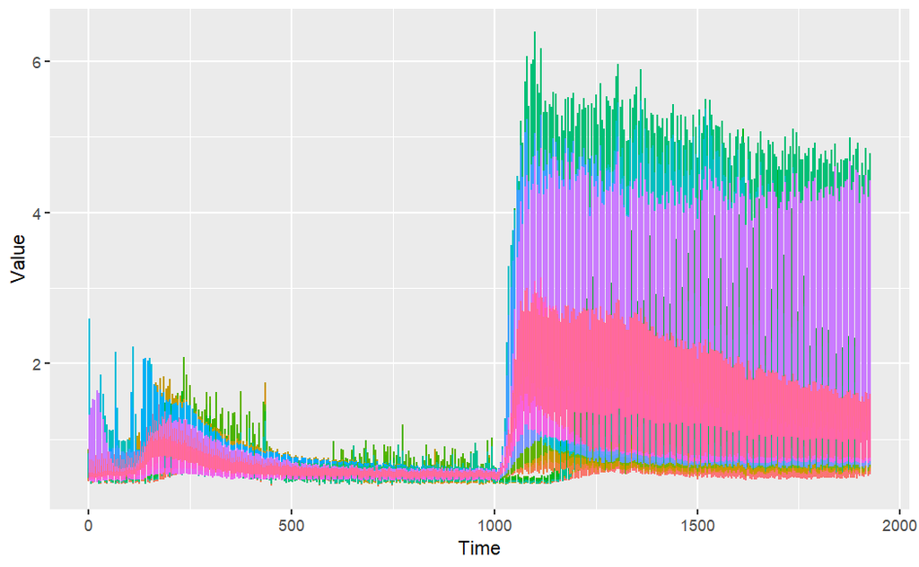

```r
ggplot(data = df_tidy,
       aes(x=Time,
           y=Value,
           group=id)) + geom_line(aes(color=Sample)) + theme(legend.position = "none")
```

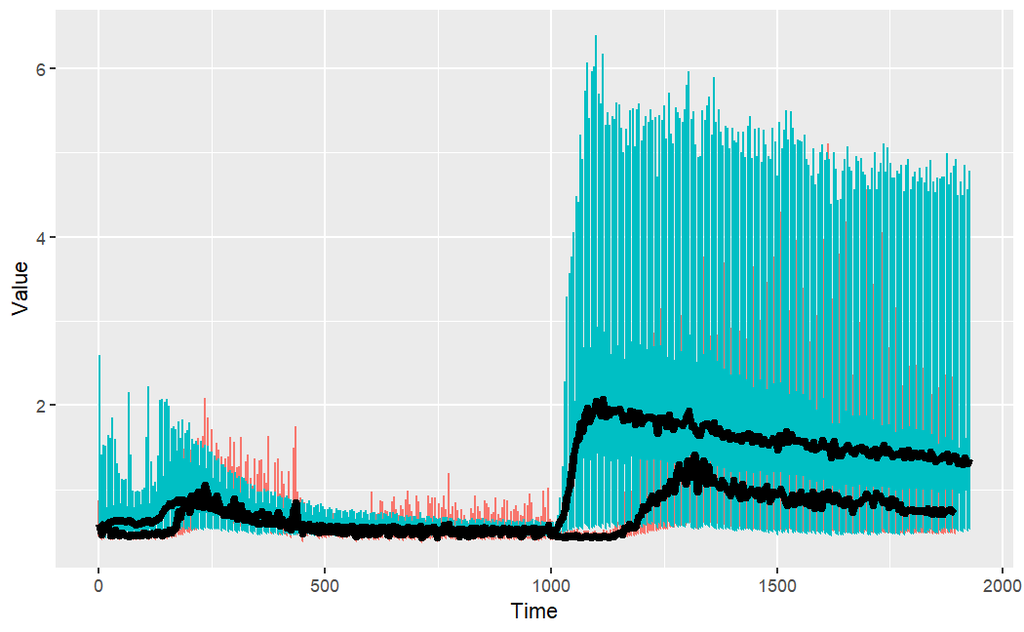

```r
ggplot(data = df_tidy,
       aes(x=Time,
           y=Value,
           group=id)) + geom_line(aes(color=id)) + theme(legend.position = "none") + stat_summary(fun = mean, geom='line', size=2)
```

Add option to the graph (change display) + save image